# EDM

2023-11-10

Se tomaron los registros de trabajo infantil provenientes del módulo correspondiente de la GEIH del 2022. Los datos que se van a analizar incluyeron a los niños que trabajan, realizan labores domésticas y asisten a la escuela. Para asegurar una cantidad de datos similar, se llevó a cabo un Muestreo Aleatorio Simple (MAS) con los niños que asisten a la escuela, seleccionando un tamaño correspondiente al de los niños que trabajan.

## Analisis exploratorio para recategorizacion

```r
summary(TI)
```

```
##    TAM_HOGAR          SEXO           EDAD
##  Min.   : 1.000   Hombre:1397   Min.   : 5.00
##  1st Qu.: 3.000   Mujer :1645   1st Qu.:12.00
##  Median : 4.000                 Median :15.00
##  Mean   : 4.672                 Mean   :13.85
##  3rd Qu.: 6.000                 3rd Qu.:17.00
##  Max.   :15.000                 Max.   :17.00
##
##                                     PARENTESCO
##  Hijo(a), hijastro(a)                    :2148
##  Nieto(a)                                : 339
##  Otro pariente                           : 148
##  Pareja, esposo(a), cónyuge, compañero(a): 143
##  Otro no pariente                        :  74
##  Yerno o nuera                           :  70
##  (Other)                                 : 120
##                                                     ESTADO_CIVIL
##  No esta casado(a) y vive en pareja hace menos de dos años: 182
##  No esta casado (a) y vive en pareja hace dos años o más  : 142
##  Esta casado (a)                                          :   2
##  Esta separado (a) o divorciado (a)                       :  29
##  Esta viudo (a)                                           :   0
##  Esta soltero (a)                                         :2214
##  NA's                                                     : 473
##       AFILIACION_SEGURIDAD_SOCIAL SABE_LEER_ESCRIBIR
##  Sí                 :2629         Sí:2811
##  No                 : 412         No: 231
##  No sabe, no informa:   1
##
##
##
##
##  ASISTE_INSTITUCION_EDUCATIVA INSTITUCION_EDUCATIVA   ANIO_GRADO     VIVE_M
##  Sí:1214                      Publica:1080          Min.   :0.000   1   :1124
##  No:1828                      Privada: 134          1st Qu.:1.000   2   : 301
##                               NA's   :1828          Median :2.000   3   :  13
##                                                     Mean   :2.258   NA's:1604
##                                                     3rd Qu.:3.000
##                                                     Max.   :5.000
##
```

[output cut: 25 more lines]

```
##  Min.   : 1.000   Min.   :      0   Min.   :1.000   Min.   : 0.000
##  1st Qu.: 4.000   1st Qu.: 177500   1st Qu.:2.000   1st Qu.: 2.000
##  Median : 7.000   Median : 323500   Median :6.000   Median : 5.000
##  Mean   : 5.906   Mean   : 392690   Mean   :4.385   Mean   : 6.025
##  3rd Qu.: 8.000   3rd Qu.: 600000   3rd Qu.:6.000   3rd Qu.: 8.000
##  Max.   :10.000   Max.   :1300000   Max.   :7.000   Max.   :83.000
##  NA's   :2489     NA's   :2820      NA's   :2489
##  SUMA_HORAS_DIA   SUMA_INDICADORAS        ACTIVIDAD_PRINCIPAL
##  Min.   : 0.000   Min.   :0.000    Estudiando       : 506
##  1st Qu.: 1.000   1st Qu.:1.000    Oficios del hogar:2030
##  Median : 2.000   Median :2.000    Trabajando       : 506
##  Mean   : 2.884   Mean   :1.487
##  3rd Qu.: 4.000   3rd Qu.:2.000
##  Max.   :29.000   Max.   :6.000
##
```

### histograma y boxplot de variables cuantitativas

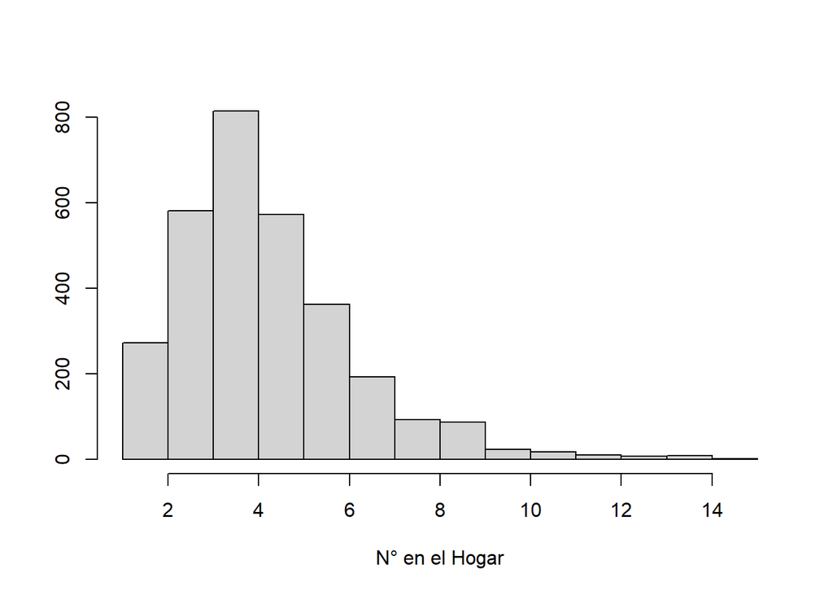

```r
hist(TI$TAM_HOGAR, xlab='N° en el Hogar',ylab = ' ', main=' ')
```

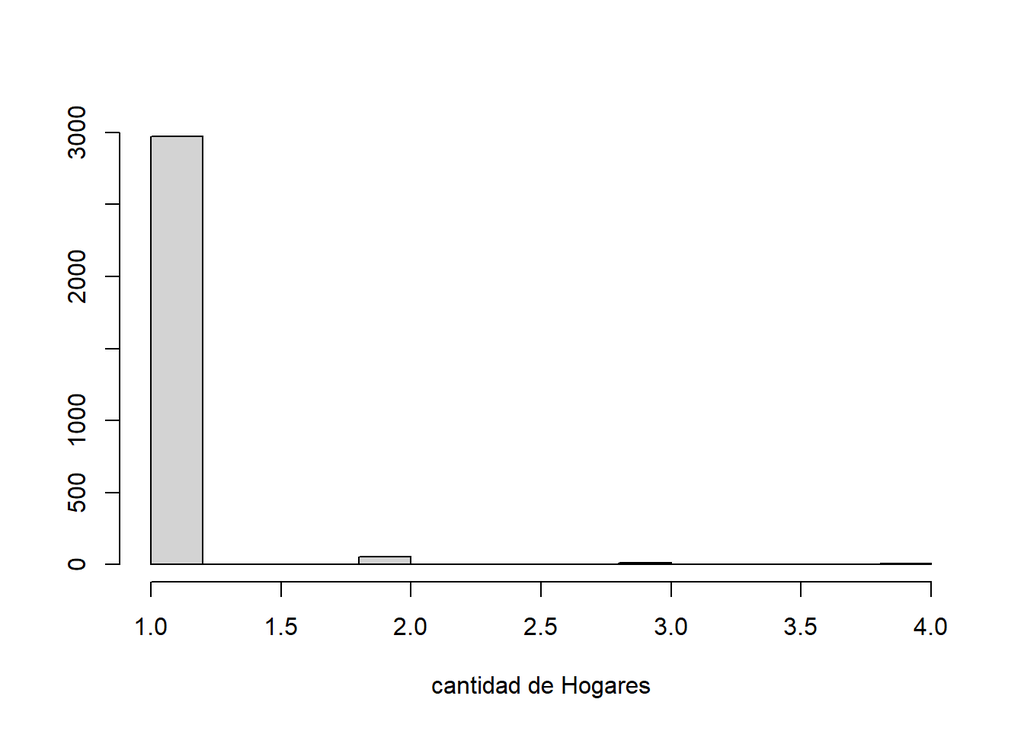

```r
hist(TI$CantHogares, xlab='cantidad de Hogares',ylab = ' ', main=' ')
```

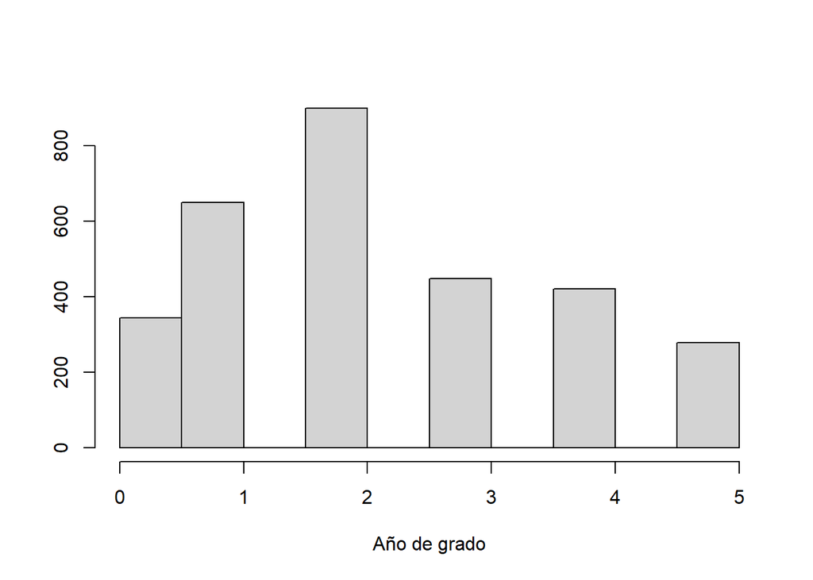

```r
hist(TI$ANIO_GRADO, xlab='Año de grado', ylab = ' ', main=' ')
```

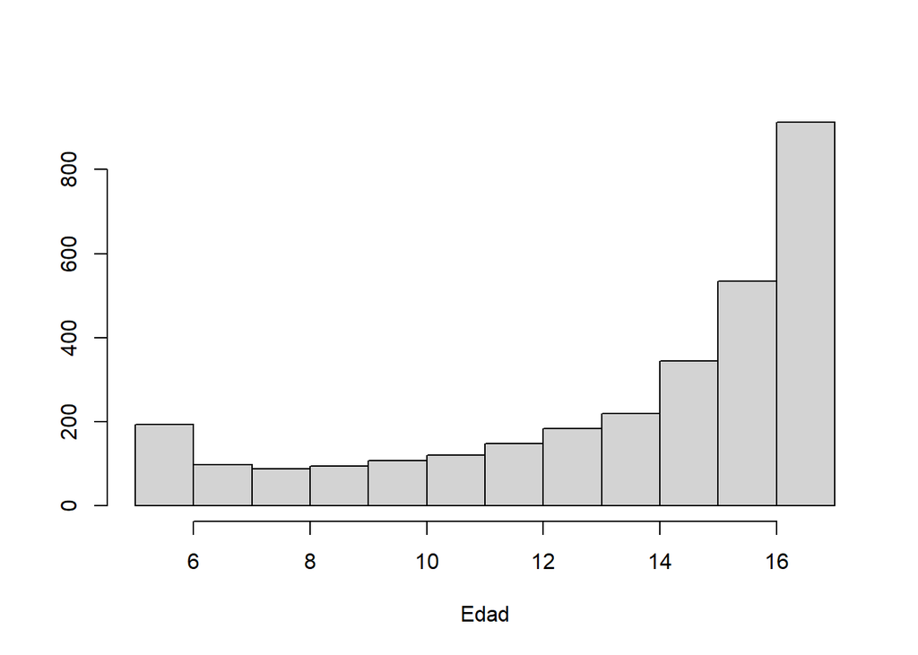

```r
hist(TI$EDAD, xlab='Edad', ylab = ' ', main=' ')
```

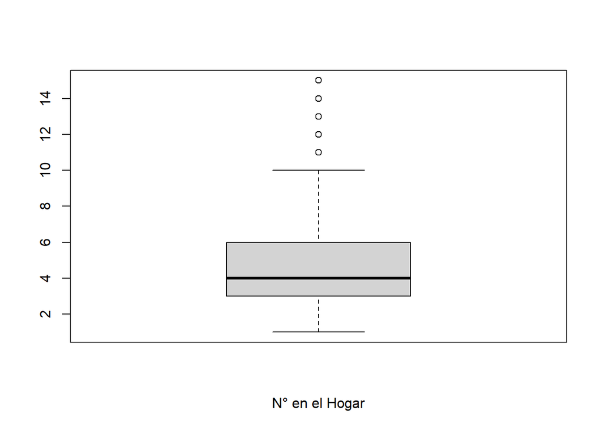

```r
boxplot(TI$TAM_HOGAR, xlab='N° en el Hogar',ylab = ' ', main=' ')
```

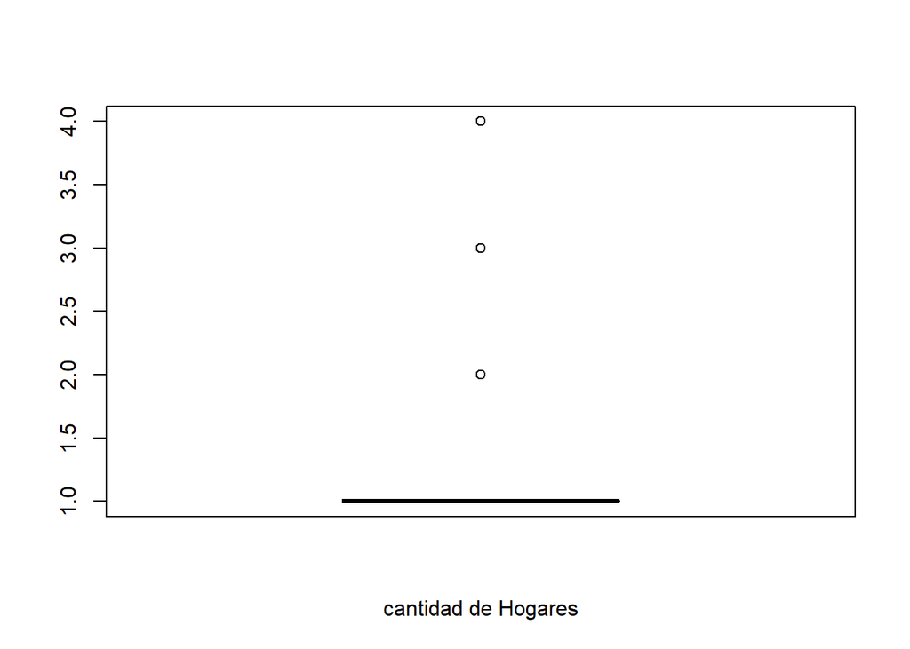

```r
boxplot(TI$CantHogares, xlab='cantidad de Hogares',ylab = ' ', main=' ')
```

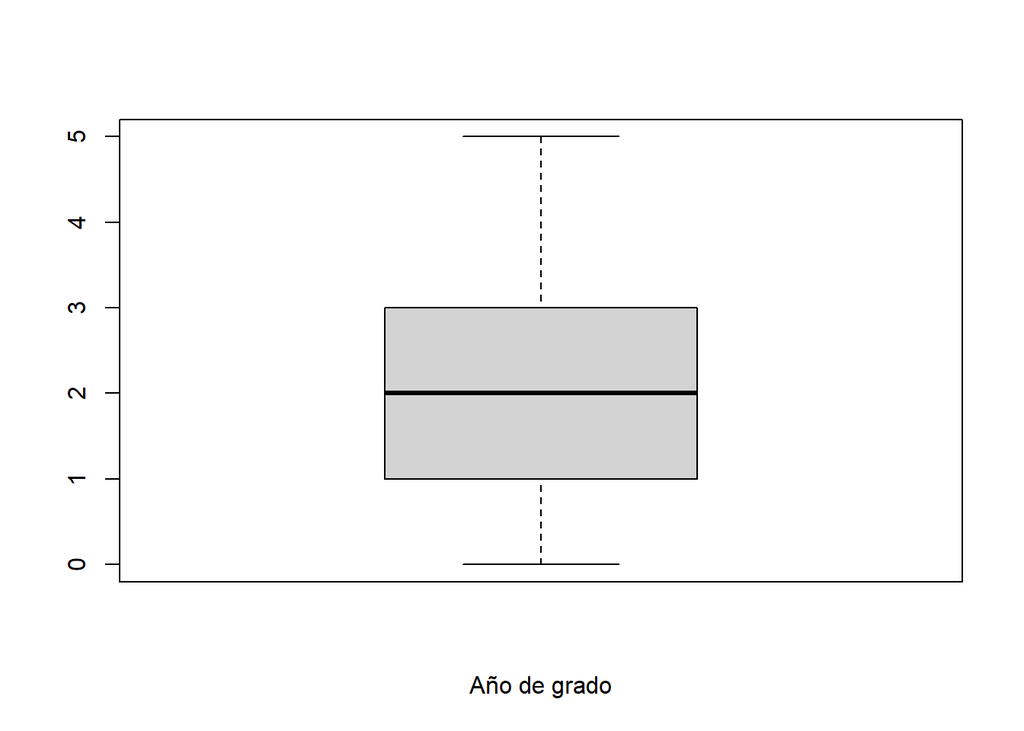

```r
boxplot(TI$ANIO_GRADO, xlab='Año de grado', ylab = ' ', main=' ')
```

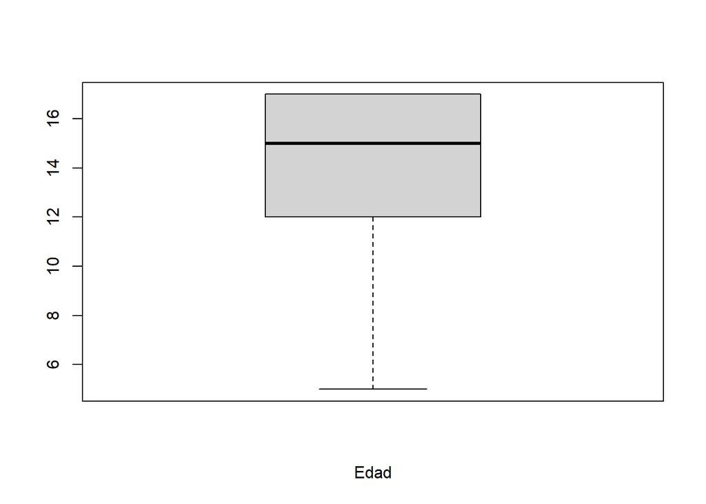

```r
boxplot(TI$EDAD, xlab='Edad', ylab = ' ', main=' ')
```

Se recategorizan las variables por sus respectivos cuantiles y se procede a hacer el ACM de los niños que trabajan, estudian o hacen oficios del hogar.

## Analisis De correspondencias Multiples

### Primer ACM

Recategorizacion TAMAN es ‘Tamaño del Hogar’, PAREN es ‘Parentesco’, ESTCI es ‘estado civil’, AFILI es AFILiADO A SEGURO SOCIAL, ESLEE es ‘sabe leer’, COLEA ‘Asiste al colegio’, COLEP ‘colegio publico o privado’, ANOGR es ‘año del grado’, MA es ‘vive con su mama’ , PA ‘vive con su papa’, CAMP ‘es campesiono’, HOGAC = ‘Clase de hogar (urbano o rural)’, DEPAR es ‘departamento’, HOGAT es ‘Tipo de hogar’ (casa apartemento o otro), HOGCA es ‘Cantidad de hogares’, ACTPR es ACtividad Principal

```r
colnames(Primero)
```

```
##  [1] "TAMAN"            "SEXO"             "EDAD"             "PAREN"
##  [5] "ESTCI"            "AFILI"            "ESLEE"            "COLEA"
##  [9] "COLEP"            "ANOGR"            "MA"               "PA"
## [13] "CAMP"             "HOGAC"            "DEPAR"            "HOGAT"
## [17] "LUZ"              "GAS"              "ALCAN"            "BASUR"
## [21] "ACUED"            "PRAWA"            "PROPI"            "HOGCA"
## [25] "P408"             "P409"             "P414"             "P420"
## [29] "P413"             "P405"             "SUMA_DIAS"        "SUMA_HORAS_DIA"
## [33] "SUMA_INDICADORAS" "ACTPR"            "EDADC"            "TAMHO"
```

```r
Activas<- Primero%>%select(COLEA,ACTPR,MA,PA,CAMP,ESTCI,GAS, ALCAN,BASUR,ACUED
        )%>%as.data.frame()


summary(Activas)
```

```
##  COLEA                   ACTPR         MA          PA         CAMP
##  Sí:1214   Estudiando       : 506   no  :1604   no  :1604   no  :1604
##  No:1828   Oficios del hogar:2030   sí  :1124   sí  : 619   sí  : 408
##            Trabajando       : 506   NA's: 314   NA's: 819   NA's:1030
##      ESTCI      GAS      ALCAN    BASUR    ACUED
##  OtroE  : 828   0:1352   0:1084   0: 593   0: 587
##  soltero:2214   1:1690   1:1958   1:2449   1:2455
##
```

```r
library(FactoClass)
```

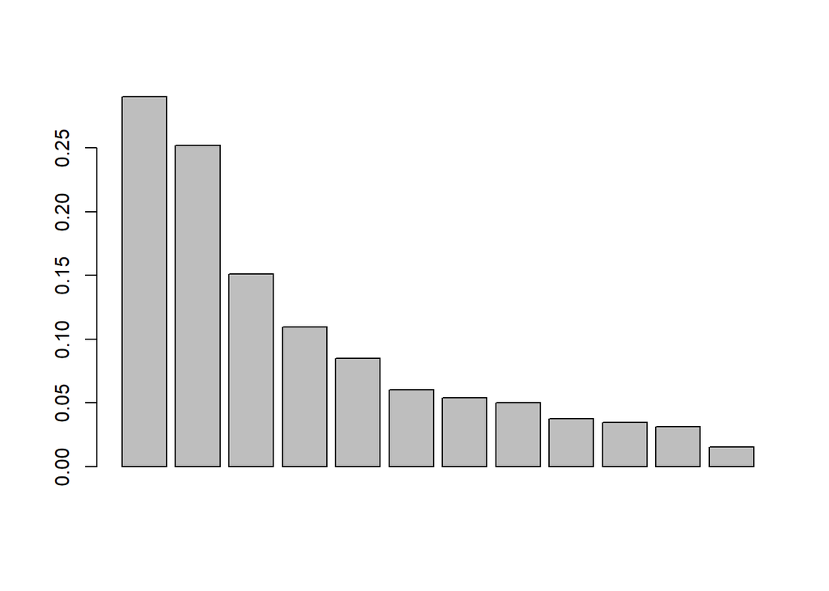

```r
acm <-dudi.acm (Activas, scannf = FALSE,nf=3)

barplot ( acm$eig)
```

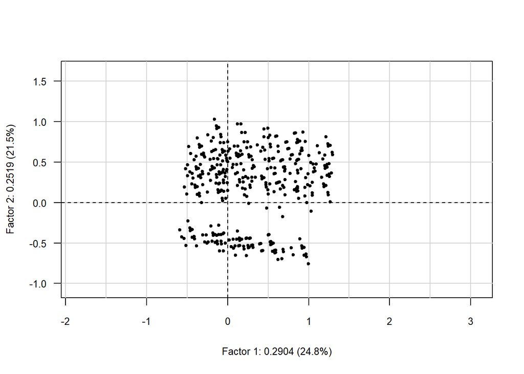

```r
ayu<-inertia.dudi(acm,,T)
plot(acm,Tcol = F,roweti = F)
```

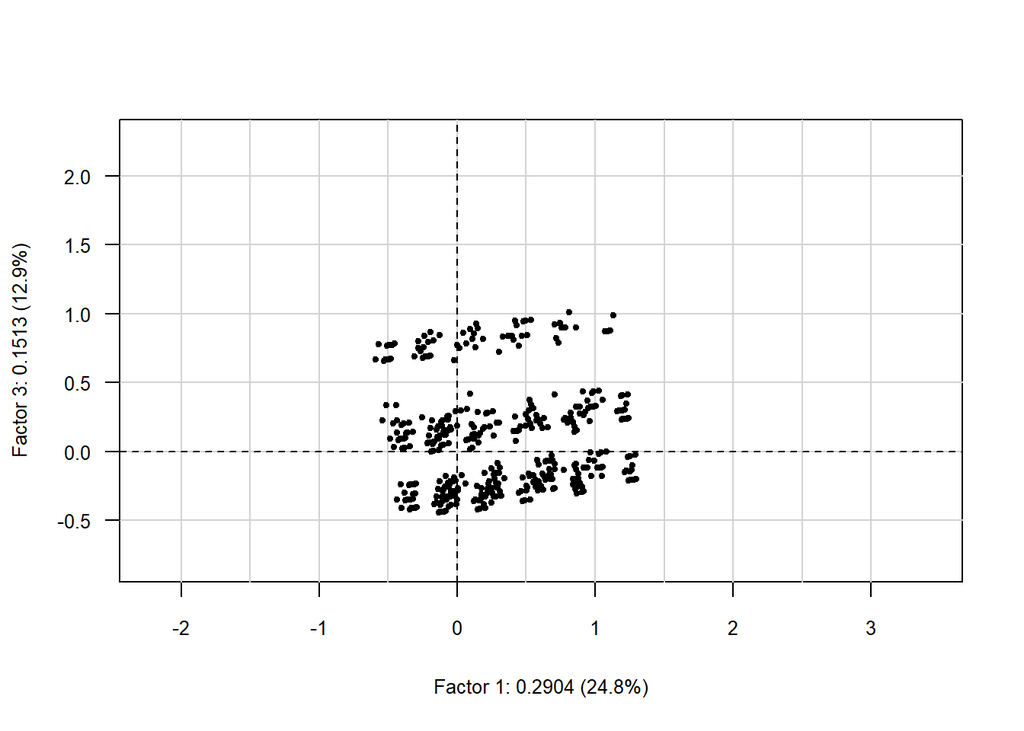

```r
plot(acm,1,3,Tcol = F,roweti = F)
```

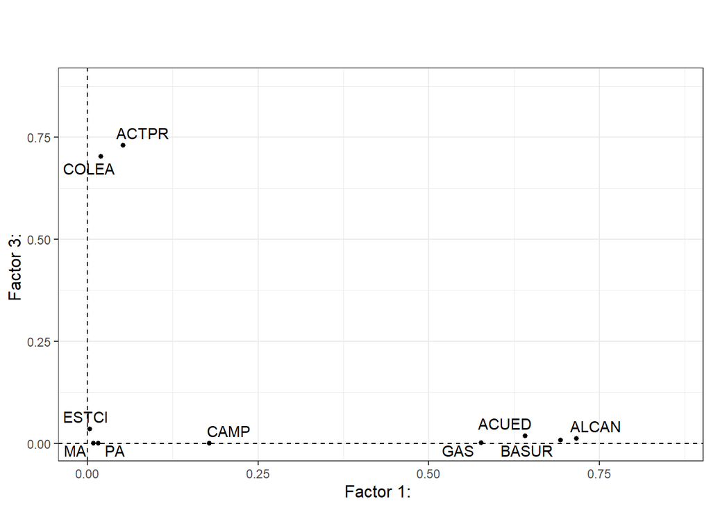

```r
plotfp(acm$cr,1,3,gg=TRUE)
```

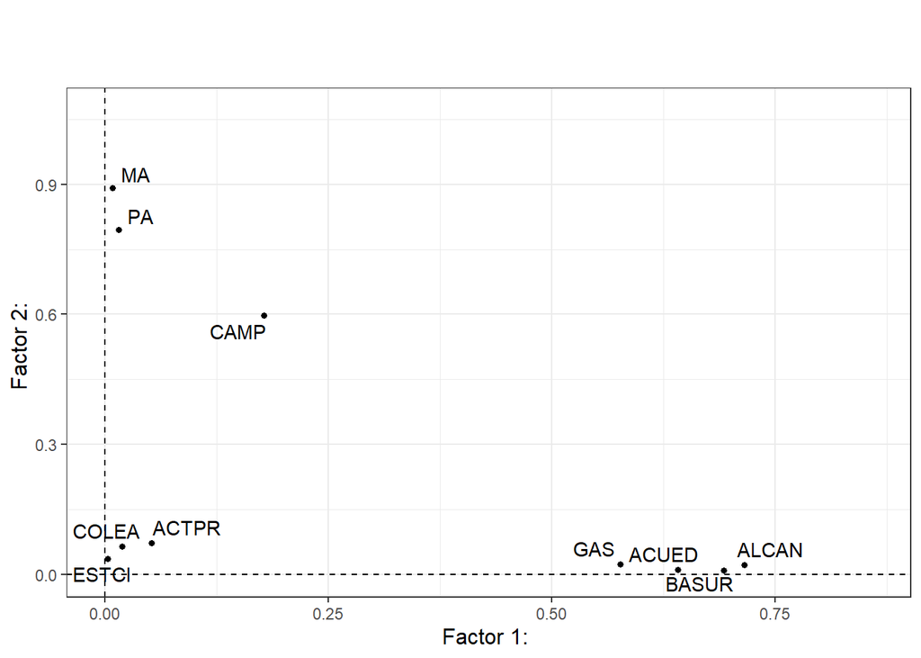

```r
plotfp(acm$cr,gg=TRUE)
```

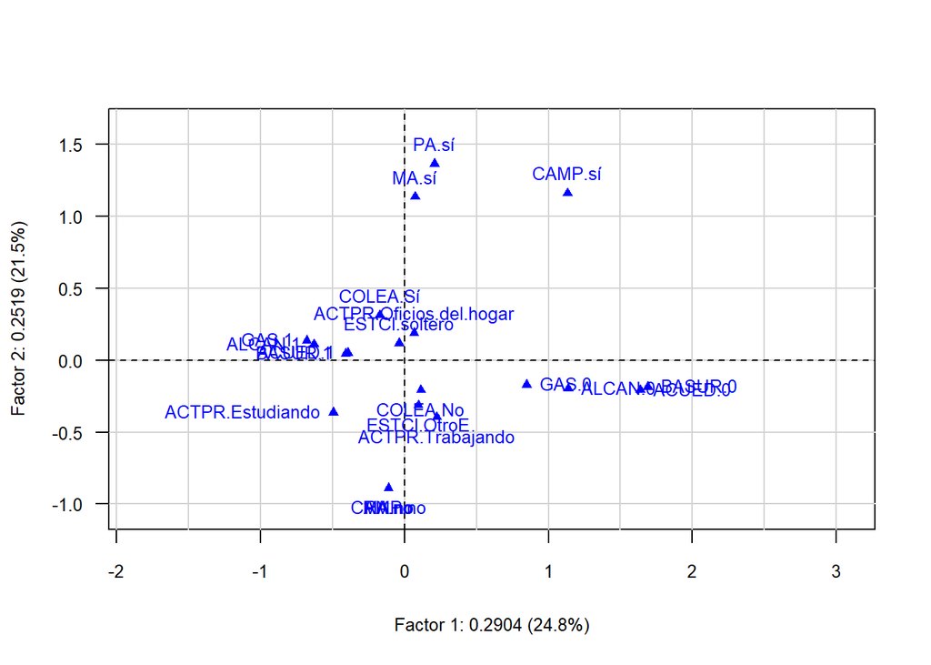

```r
plot(acm,Trow = F)
```

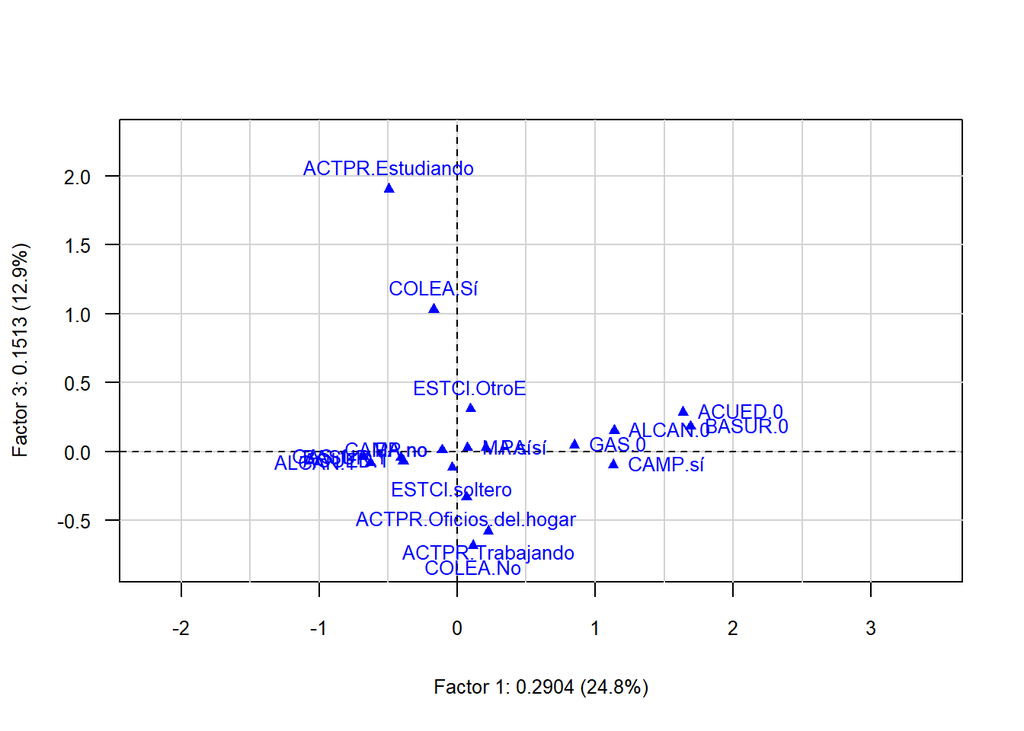

```
##                          peso  Comp1  Comp2  Comp3 Axis1 Axis2 Axis3 Axis1
## COLEA.Sí                3.991 -0.172  0.312  1.029 0.004 0.015 0.279 0.020
## COLEA.No                6.009  0.114 -0.207 -0.683 0.003 0.010 0.185 0.020
## ACTPR.Estudiando        1.663 -0.495 -0.363  1.903 0.014 0.009 0.398 0.049
## ACTPR.Oficios del hogar 6.673  0.067  0.189 -0.331 0.001 0.009 0.048 0.009
## ACTPR.Trabajando        1.663  0.225 -0.395 -0.576 0.003 0.010 0.036 0.010
## MA.no                   5.273 -0.112 -0.888  0.012 0.002 0.165 0.000 0.014
## MA.sí                   3.695  0.074  1.134  0.029 0.001 0.189 0.000 0.003
## PA.no                   5.273 -0.112 -0.888  0.012 0.002 0.165 0.000 0.014
## PA.sí                   2.035  0.207  1.364  0.026 0.003 0.150 0.000 0.011
## CAMP.no                 5.273 -0.112 -0.888  0.012 0.002 0.165 0.000 0.014
## CAMP.sí                 1.341  1.131  1.160 -0.097 0.059 0.072 0.001 0.198
## ESTCI.OtroE             2.722  0.096 -0.312  0.309 0.001 0.011 0.017 0.003
## ESTCI.soltero           7.278 -0.036  0.117 -0.116 0.000 0.004 0.006 0.003
## GAS.0                   4.444  0.849 -0.170  0.047 0.110 0.005 0.001 0.577
## GAS.1                   5.556 -0.679  0.136 -0.038 0.088 0.004 0.001 0.577
## ALCAN.0                 3.563  1.137 -0.198  0.152 0.159 0.006 0.005 0.716
## ALCAN.1                 6.437 -0.629  0.110 -0.084 0.088 0.003 0.003 0.716
## BASUR.0                 1.949  1.691 -0.187  0.183 0.192 0.003 0.004 0.693
## BASUR.1                 8.051 -0.410  0.045 -0.044 0.047 0.001 0.001 0.693
## ACUED.0                 1.930  1.637 -0.207  0.286 0.178 0.003 0.010 0.641
## ACUED.1                 8.070 -0.391  0.050 -0.068 0.043 0.001 0.002 0.641
##                         Axis2 Axis3
## COLEA.Sí                0.065 0.703
## COLEA.No                0.065 0.703
## ACTPR.Estudiando        0.026 0.722
## ACTPR.Oficios del hogar 0.072 0.219
## ACTPR.Trabajando        0.031 0.066
## MA.no                   0.880 0.000
## MA.sí                   0.753 0.000
## PA.no                   0.880 0.000
## PA.sí                   0.476 0.000
## CAMP.no                 0.880 0.000
## CAMP.sí                 0.208 0.001
## ESTCI.OtroE             0.036 0.036
## ESTCI.soltero           0.036 0.036
## GAS.0                   0.023 0.002
## GAS.1                   0.023 0.002
## ALCAN.0                 0.022 0.013
## ALCAN.1                 0.022 0.013
## BASUR.0                 0.008 0.008
## BASUR.1                 0.008 0.008
## ACUED.0                 0.010 0.019
## ACUED.1                 0.010 0.019
```

```r
plot(acm,1,3,Trow = F)
```

Podemos observar que el primer eje separa a los niños que viven en el campo y no tienen acceso a servicios. El segundo eje distingue los oficios del hogar, indicando que los niños que viven en el campo lo hacen con ambos padres.

### Varaibles suplementarias

```r
library(dplyr)
Ilus<- Primero%>%select(-c(EDAD,TAMAN,ANOGR, HOGCA ,DEPAR,P408, P409, P414, P420, P413, P405,COLEA,ACTPR,MA,PA,CAMP,ESTCI,GAS, ALCAN,BASUR,ACUED, SUMA_DIAS,SUMA_HORAS_DIA ,SUMA_INDICADORAS )
        )%>%as.data.frame()


summary(Ilus)
```

```
##      SEXO        PAREN                      AFILI      ESLEE         COLEP
##  Hombre:1397   H    :2148   Sí                 :2629   Sí:2811   Publica:1080
##  Mujer :1645   N    : 339   No                 : 412   No: 231   Privada: 134
##                OtroP: 555   No sabe, no informa:   1             NA's   :1828
##
##     HOGAC         HOGAT      LUZ              PRAWA           PROPI
##  Rural : 610   Apto  : 978   0:  97   Naturaleza : 248   Arriendo:1303
##  Urbano:2432   Casa  :1953   1:2945   Otros      : 131   Otro    : 977
##                Cuarto:  63            Tecnificado:2663   Propia  : 762
##                Otro  :  48
##    EDADC      TAMHO
##  14-  :1032   1-2: 272
##  14-15: 564   3-4:1395
##  15+  :1446   4+ :1375
##
```

```r
supcar <- supqual ( acm , Ilus)

round(cbind(Indice=seq(1:length(supcar$tv[,1])), supcar$tv),3)
```

```
##                           Indice   Axis1   Axis2   Axis3
## SEXO.Hombre                    1  -0.288  -2.862   0.462
## SEXO.Mujer                     2   0.288   2.862  -0.462
## PAREN.H                        3  -0.733  12.236   3.784
## PAREN.N                        4  -4.863  -2.483   4.587
## PAREN.OtroP                    5   4.827 -12.410  -8.200
## AFILI.Sí                       6  -0.442   7.864  10.244
## AFILI.No                       7   0.452  -7.810 -10.217
## AFILI.No sabe, no informa      8  -0.181  -1.188  -0.717
## ESLEE.Sí                       9   0.056   5.672  -3.217
## ESLEE.No                      10  -0.056  -5.672   3.217
## COLEP.Publica                 11  -4.385  13.663  42.535
## COLEP.Privada                 12  -8.213   1.618  11.173
## HOGAC.Rural                   13  39.562  -5.008   3.221
## HOGAC.Urbano                  14 -39.562   5.008  -3.221
## HOGAT.Apto                    15 -21.792   1.853  -2.123
## HOGAT.Casa                    16  17.785  -2.348   1.516
## HOGAT.Cuarto                  17   0.586  -1.204  -1.914
## HOGAT.Otro                    18  12.583   3.462   4.315
## LUZ.0                         19  18.803   0.108   3.286
## LUZ.1                         20 -18.803  -0.108  -3.286
## PRAWA.Naturaleza              21  24.513  -3.836   4.257
## PRAWA.Otros                   22   4.134  -0.344   3.883
## PRAWA.Tecnificado             23 -22.852   3.390  -5.914
## PROPI.Arriendo                24 -21.095  -0.728  -5.158
## PROPI.Otro                    25  21.601  -0.920   2.663
## PROPI.Propia                  26   0.813   1.823   3.022
## EDADC.14-                     27  -3.578   1.486  23.627
## EDADC.14-15                   28   1.557   2.125  -0.465
## EDADC.15+                     29   2.181  -3.063 -22.038
## TAMHO.1-2                     30   1.967  -3.916  -3.884
## TAMHO.3-4                     31  -3.136   2.074   3.299
## TAMHO.4+                      32   2.012   0.169  -1.076
```

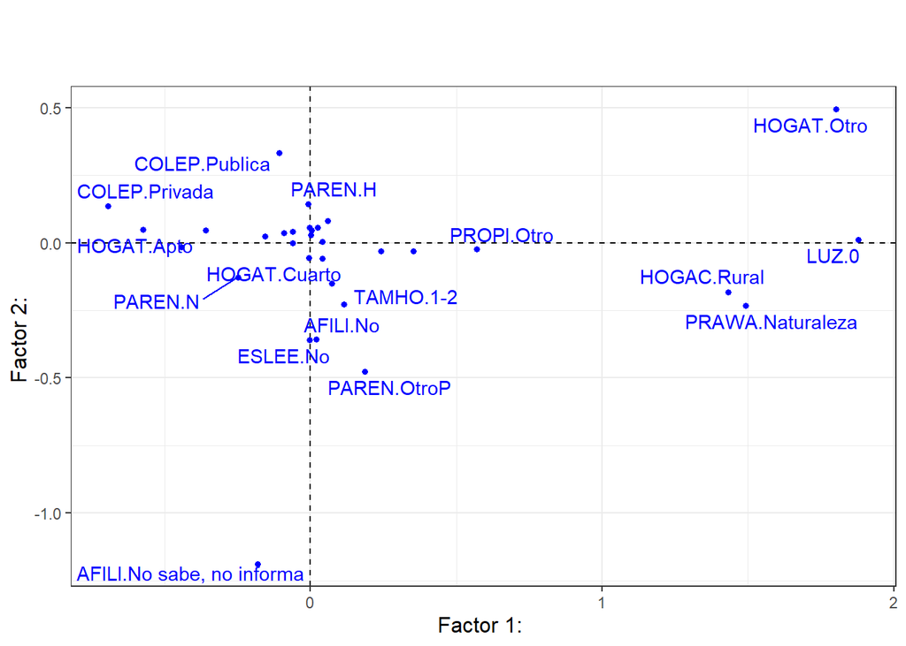

```r
library(FactoClass)

plotfp(as.data.frame(supcar$coor[,1:2]),col="blue",cframe=1,gg=TRUE)
```

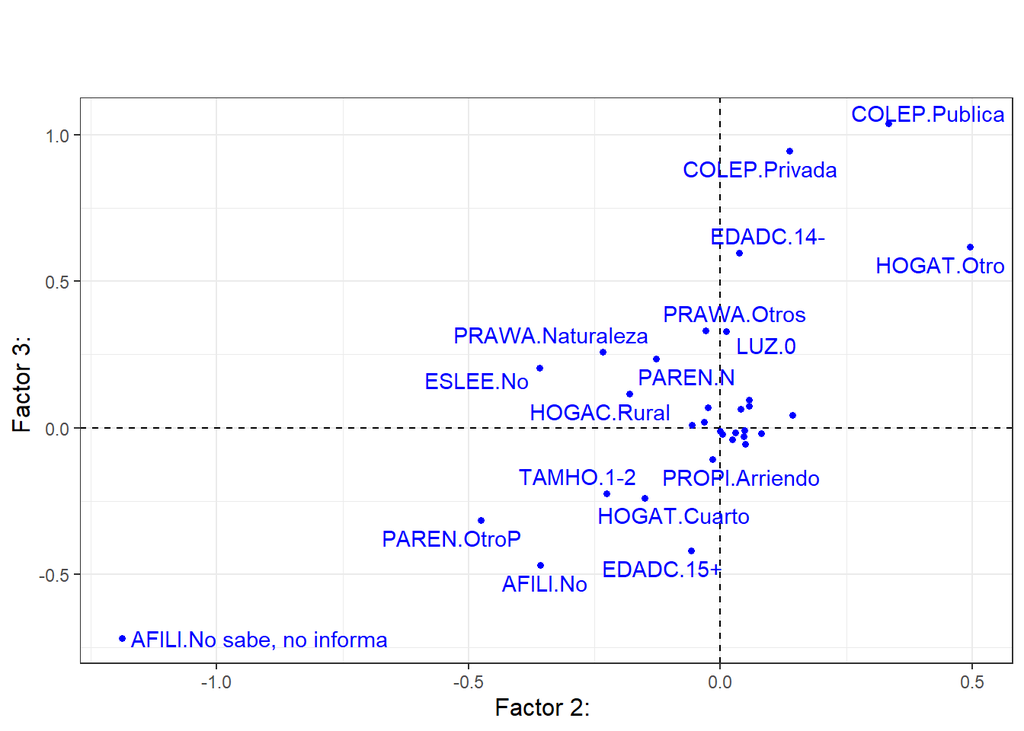

```r
plotfp(as.data.frame(supcar$coor),x=2,y=3,col="blue",cframe=1,gg=TRUE)
```

## Cluster

```r
help("FactoClass")
```

```
## starting httpd help server ... done
```

```r
clus<-FactoClass(Activas,dudi.acm,nf=3,k.clust = 3,scanFC = FALSE)
```

```
## The number of retained axes for factorial analysis is  3
##
## The number of axes for clustering is  10
```

```
## Look the histogram of 25 indexes
## Partition in  3  clusters
```

```r
clus$clus.summ
```

```
##       Bef.Size Aft.Size Bef.Inertia Aft.Inertia Bef.Weight Aft.Weight
## 1          646      713      0.2051      0.2398     0.2124     0.2344
## 2         1544     1232      0.4233      0.2328     0.5076     0.4050
## 3          852     1097      0.1532      0.2457     0.2801     0.3606
## TOTAL     3042     3042      0.7816      0.7183     1.0001     1.0000
##       Bef.Dist_2 Aft.Dist_2
## 1         0.7316     0.7729
## 2         0.1283     0.2592
## 3         0.3824     0.3152
## TOTAL         NA         NA
```

```r
clus$carac.cate
```

```
## class: 1
##                  Test.Value p.Value Class.Cat Cat.Class Global Weight
## ALCAN.0                 Inf   0.000      65.6      99.7   35.6   1084
## BASUR.0                 Inf   0.000      96.5      80.2   19.5    593
## ACUED.0                 Inf   0.000      93.7      77.1   19.3    587
## GAS.0                35.972   0.000      51.8      98.3   44.4   1352
## CAMP.sí              14.828   0.000      54.7      31.3   13.4    408
## ACTPR.Trabajando      4.724   0.000      31.6      22.4   16.6    506
## ESTCI.OtroE           3.917   0.000      28.3      32.8   27.2    828
## COLEA.No              2.375   0.018      24.8      63.5   60.1   1828
## PA.sí                 2.133   0.033      26.3      22.9   20.3    619
## COLEA.Sí             -2.375   0.018      21.4      36.5   39.9   1214
## ESTCI.soltero        -3.917   0.000      21.6      67.2   72.8   2214
## ACTPR.Estudiando     -4.314   0.000      16.4      11.6   16.6    506
## GAS.1               -35.972   0.000       0.7       1.7   55.6   1690
## ALCAN.1                -Inf   0.000       0.1       0.3   64.4   1958
## BASUR.1                -Inf   0.000       5.8      19.8   80.5   2449
## ACUED.1                -Inf   0.000       6.6      22.9   80.7   2455
## ------------------------------------------------------------
## class: 2
##                         Test.Value p.Value Class.Cat Cat.Class Global Weight
## MA.no                          Inf   0.000      76.8     100.0   52.7   1604
## PA.no                          Inf   0.000      76.8     100.0   52.7   1604
## CAMP.no                        Inf   0.000      76.8     100.0   52.7   1604
## BASUR.1                     23.560   0.000      49.6      98.6   80.5   2449
## ACUED.1                     22.814   0.000      49.3      98.3   80.7   2455
## ALCAN.1                     16.846   0.000      51.4      81.7   64.4   1958
## GAS.1                       13.110   0.000      50.8      69.7   55.6   1690
## ACTPR.Estudiando             9.856   0.000      60.3      24.8   16.6    506
## COLEA.No                     7.385   0.000      45.8      67.9   60.1   1828
## ACTPR.Trabajando             2.043   0.041      44.1      18.1   16.6    506
## COLEA.Sí                    -7.385   0.000      32.5      32.1   39.9   1214
## ACTPR.Oficios del hogar     -9.261   0.000      34.7      57.1   66.7   2030
## GAS.0                      -13.110   0.000      27.6      30.3   44.4   1352
## ALCAN.0                    -16.846   0.000      20.8      18.3   35.6   1084
## CAMP.sí                    -21.434   0.000       0.0       0.0   13.4    408
## ACUED.0                    -22.814   0.000       3.6       1.7   19.3    587
## BASUR.0                    -23.560   0.000       2.9       1.4   19.5    593
## PA.sí                      -27.222   0.000       0.0       0.0   20.3    619
## MA.sí                         -Inf   0.000       0.0       0.0   36.9   1124
```

[output cut: 9 more lines]

```
## ACTPR.Oficios del hogar     10.142       0      42.2      78.0   66.7   2030
## COLEA.Sí                     9.351       0      46.0      51.0   39.9   1214
## ESTCI.soltero                4.521       0      38.4      77.5   72.8   2214
## CAMP.sí                      4.250       0      45.3      16.9   13.4    408
## ESTCI.OtroE                 -4.521       0      29.8      22.5   27.2    828
## ACTPR.Trabajando            -6.235       0      24.3      11.2   16.6    506
## ACTPR.Estudiando            -6.765       0      23.3      10.8   16.6    506
## COLEA.No                    -9.351       0      29.4      49.0   60.1   1828
## GAS.0                      -16.201       0      20.6      25.3   44.4   1352
## ALCAN.0                    -20.097       0      13.6      13.4   35.6   1084
## ACUED.0                    -21.452       0       2.7       1.5   19.3    587
## BASUR.0                    -23.647       0       0.7       0.4   19.5    593
## MA.no                         -Inf       0       0.0       0.0   52.7   1604
## PA.no                         -Inf       0       0.0       0.0   52.7   1604
## CAMP.no                       -Inf       0       0.0       0.0   52.7   1604
```

```r
Ilus<-cbind(Ilus,Cluster=as.factor(clus$cluster))
```

```r
supcar <- supqual ( acm , Ilus)
```

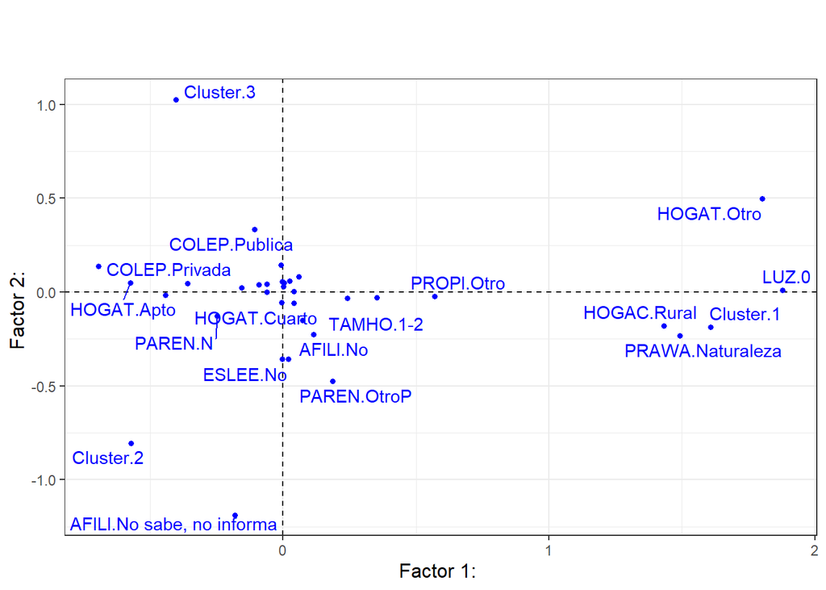

```r
plotfp(as.data.frame(supcar$coor),col="blue",cframe=1,gg=TRUE)
```

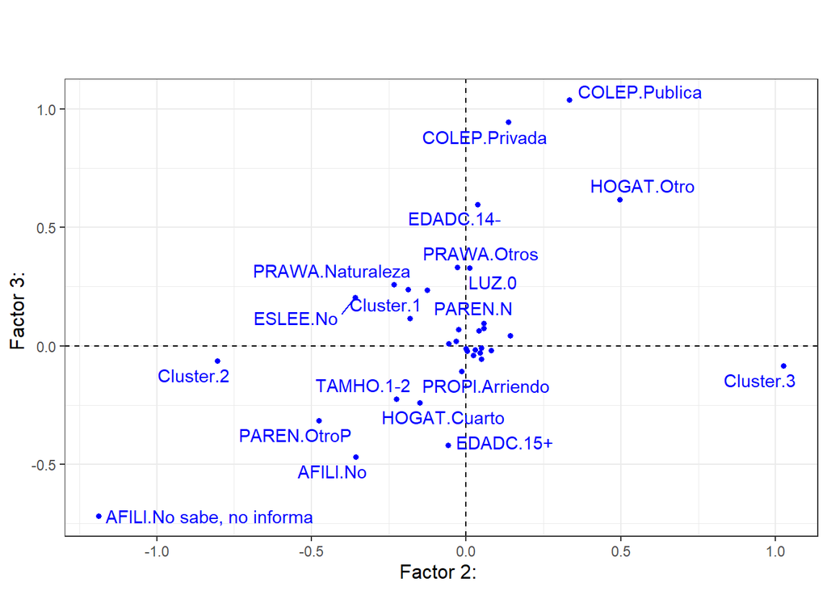

```r
plotfp(as.data.frame(supcar$coor),x=2,y=3,col="blue",cframe=1,gg=TRUE)
```